# MODELING SUD TREATMENT READMISSION WITH A RECURRENT TIME-TO-EVENT APPROACH

2022-03-25

## Antecedentes

- El consumo indebido de sustancias se relaciona con múltiples problemas de salud(Rehm et al., 2009):
  - Enfermedades cardiacas(Degenhardt et al., 2013)
  - Ansiedad y síntomas de psicosis(Castillo-Carniglia et al., 2019)
  - Conductas sexuales de riesgo(Chawla y Sarkar,2019)
- Los programas de rehabilitación son el principal mecanismo para abordar este problema
  - Más del 60% del presupuesto de SENDA está destinado al tratamiento

## ¿Qué se sabe de los programas de rehabilitación?

- Se relaciona con diversos beneficios
  - Reducir mortalidad asociada al consumo
  - Reducir comorbilidades psiquiátricas
  - Mejorar calidad de vida
- La tasa de abandonos es alta
- La remisión es difícil de alcanzar
  - En Chile durante 2018, solo el 23% alcanzó el alta terapéutica

## Readmisión

- Condición de recaídas crónicas
- Sobreuso del sistema sanitario
  - Listas de espera
- Mantención del logro terapéutico al largo plazo
- Readmisión \(\neq\) Recaída
- Es un evento recurrente

## Eventos recurrentes

- Eventos reversibles/irreversibles
- Reversibles -> Multiples (hospitalización) o Recurrentes (readmisión)
- Dos características principales:
  - Correlación intra-individuo
  - Covariables time-variant
- ¿De dónde viene la correlación?
  - Dependencia
  - Heterogeneidad

## ¿Por qué necesitamos teorizar sobre esto?

- Los modelos clásicos de supervivencia se centran en el primer evento (COXPH)
- Los errores estándar pueden estar mal estimados si no consideramos la correlación
- Modelos de varianza corregida (Yadav et al., 2018)
  - Andersen Gil (AG)
  - **Prentice, Williams y Petersen (PWP)**
  - Frailty
  - Wei, Lin y Weissfeld (WLW)

## Materiales y método

- SISTRAT
  - 10 años de seguimiento
- Random forest imputation (~8% de perdidos)
- Modelos PWP
  - Total Time (TT)
  - Gap Time (GT)
- Interacción con estrato (N° de admisión)
  - <= 3 Admisiones
- Bootstrap paramétrico para obtener IC de la combinación no lineal con transformación (\(\exp\))
- n = 107.665

## Resultados

**Estimated PWP-TT and PWP-GT models**

|  | PWP-TT Raw | PWP-TT imp | PWP-GT Raw | PWP-GT imp |
| --- | --- | --- | --- | --- |
| Therapeutic Discharge | 0.80 (0.77, 0.84) | 0.79 (0.75, 0.82) | 0.81 (0.77, 0.85) | 0.79 (0.76, 0.83) |
| Female | 1.22 (1.18, 1.26) | 1.21 (1.18, 1.25) | 1.21 (1.17, 1.25) | 1.21 (1.17, 1.24) |
| Age of onset | 0.99 (0.99, 1.00) | 0.99 (0.99, 0.99) | 1.00 (0.99, 1.00) | 0.99 (0.99, 0.99) |
| Separated | 1.02 (0.97, 1.07) | 1.01 (0.96, 1.05) | 1.02 (0.97, 1.06) | 1.00 (0.96, 1.05) |
| Single | 0.95 (0.92, 0.98) | 0.97 (0.94, 1.00) | 0.94 (0.91, 0.98) | 0.96 (0.93, 0.99) |
| Widower | 0.89 (0.75, 1.04) | 0.90 (0.77, 1.04) | 0.90 (0.76, 1.04) | 0.91 (0.77, 1.04) |
| Cocaine | 1.21 (1.17, 1.25) | 1.19 (1.14, 1.23) | 1.20 (1.16, 1.24) | 1.18 (1.14, 1.22) |
| Marijuana | 0.92 (0.86, 0.99) | 0.86 (0.79, 0.93) | 0.94 (0.87, 1.01) | 0.88 (0.82, 0.95) |
| Other subs | 1.03 (0.92, 1.14) | 0.96 (0.85, 1.07) | 1.06 (0.95, 1.17) | 0.99 (0.88, 1.09) |
| Cocaine Paste | 1.41 (1.38, 1.45) | 1.38 (1.34, 1.41) | 1.42 (1.39, 1.46) | 1.39 (1.35, 1.42) |
| Secondary ed | 0.91 (0.87, 0.94) | 0.91 (0.88, 0.95) | 0.91 (0.88, 0.95) | 0.92 (0.88, 0.95) |
| Primary ed | 0.76 (0.72, 0.80) | 0.76 (0.72, 0.80) | 0.78 (0.74, 0.82) | 0.78 (0.74, 0.82) |
| Moderate compromise | 1.07 (1.02, 1.13) | 1.08 (1.03, 1.14) | 1.08 (1.02, 1.13) | 1.08 (1.03, 1.14) |
| Severe compromise | 1.33 (1.27, 1.39) | 1.32 (1.27, 1.38) | 1.34 (1.29, 1.40) | 1.33 (1.28, 1.39) |
| Woman specific | 1.27 (1.22, 1.32) | 1.29 (1.24, 1.33) | 1.25 (1.21, 1.30) | 1.27 (1.23, 1.32) |
| Employee | 0.89 (0.86, 0.92) | 0.91 (0.88, 0.94) | 0.89 (0.86, 0.93) | 0.91 (0.88, 0.94) |
| Inactive | 0.92 (0.89, 0.96) | 0.96 (0.93, 1.00) | 0.93 (0.89, 0.96) | 0.96 (0.92, 1.00) |
| Freq | 1.00 (1.00, 1.01) | 1.01 (1.00, 1.01) | 1.00 (0.99, 1.01) | 1.00 (1.00, 1.01) |
| Age | 0.99 (0.99, 0.99) | 0.99 (0.99, 0.99) | 0.99 (0.99, 0.99) | 0.99 (0.99, 0.99) |
| TD x Strata2 | 0.99 (0.91, 1.08) | 1.01 (0.93, 1.10) | 1.00 (0.92, 1.08) | 1.01 (0.93, 1.09) |
| TD x Strata3 | 1.09 (0.96, 1.23) | 1.12 (0.98, 1.26) | 1.05 (0.91, 1.19) | 1.06 (0.93, 1.20) |

## Intervalos de confianza

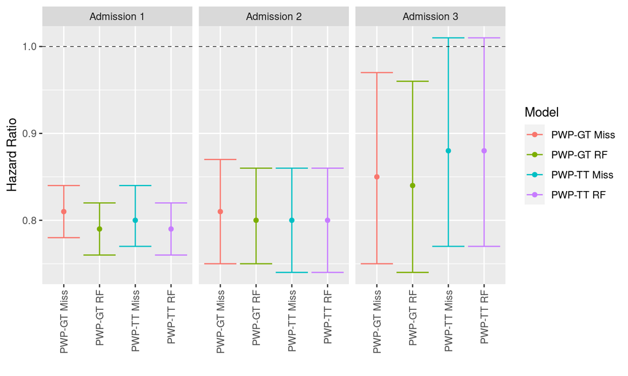

## Discusión

- Los programas de rehabilitación disminuyen el riesgo de readmisión si se completan satisfactoriamente
- Hay que tener especial precaución con los consumidores de Pasta Base y Cocaína
- No se observa una diferencia significativa en el efecto del tratamiento para las admisiones posteriores
- Es importante desarrollar estrategias para disminuir el abandono y/o aumentar el alta terapéutica
- Trabajos posteriores deben enfocarse en identificar elementos que aumenten el tiempo entre el alta y la recaída, a la vez que disminuyan el tiempo entre la recaída y la readmisión

## Bibliografía

- Castillo-Carniglia, A., Keyes, K. M., Hasin, D. S., & Cerdá, M. (2019). Psychiatric comorbidities in alcohol use disorder. The Lancet Psychiatry, 6(12), 1068–1080
- Chawla, N., & Sarkar, S. (2019). Defining “High-risk Sexual Behavior” in the Context of Substance Use. Journal of Psychosexual Health, 1(1), 26–31
- Degenhardt, L., Whiteford, H. A., Ferrari, A. J., Baxter, A. J., Charlson, F. J., Hall, W. D., Freedman, G., Burstein, R., Johns, N., Engell, R. E., Flaxman, A., Murray, C. J. L., & Vos, T. (2013). Global burden of disease attributable to illicit drug use and dependence: Findings from the Global Burden of Disease Study 2010. The Lancet, 382(9904), 1564–1574
- Pasareanu, A. R., Opsal, A., Vederhus, J. K., Kristensen, Ø., & Clausen, T. (2015). Quality of life improved following in-patient substance use disorder treatment. Health and Quality of Life Outcomes, 13(1), 1–8
- Prentice, R. L., Williams, B. J., & Peterson, A. V. (1981). On the regression analysis of multivariate failure time data. Biometrika, 68(2), 373–379
- Yadav, C. P., V, S., MA, K., & RM, P. (2018). An Overview of Statistical Models for Recurrent Events Analysis: A Review. Epidemiology: Open Access, 08(04)